# Tidy Tuesday - Week 8 (2021)

Julia Tache

2/16/2021

## Dubois Challenge

This was a rather challenging week! I managed to replicate two graphs that I’m happy with that follow Du Bois’ principles. Focusing on the aesthetic presentation of these graphs was the hardest part for me, and it made me realize how much growth I have ahead of me in terms of my own visualizations and presentations. Learning about Du Bois’ work and style as well as the project he put together to present a detailed picture of African-American life in 1900 was very exciting.

I hope to keep updating this particular file this week with more graphs, so stay tuned!

About the data: Anthony Starks, Allen Hillery, and Sekou Tyler put together a very cool data challenge as part of a longer celebration of “the data visualization legacy of W.E.B DuBois by recreating the visualizations from the 1900 Paris Exposition using modern tools.”

Source: https://github.com/rfordatascience/tidytuesday/tree/master/data/2021/2021-02-16

```r
library(tidyverse)
tuesdata <- tidytuesdayR::tt_load('2021-02-16')
```

challenge01: Comparative Increase of White and Colored Population in Georgia

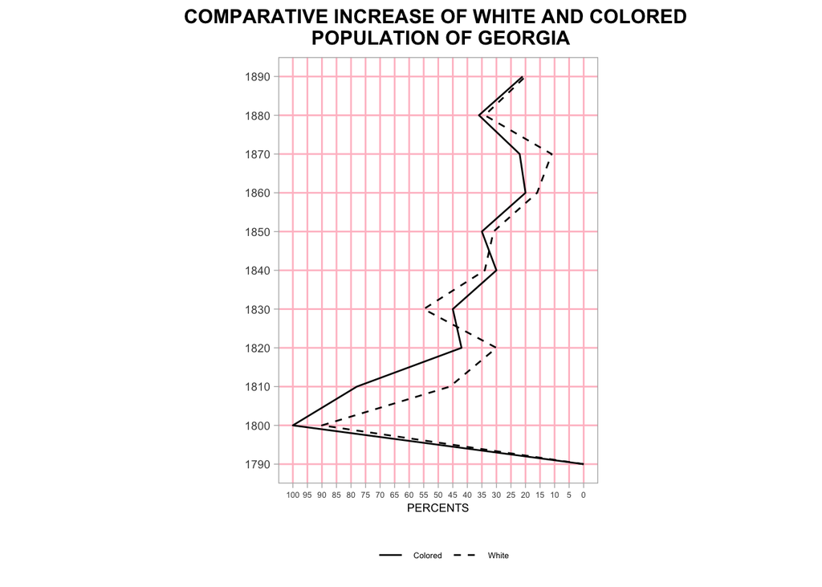

```r
library(reshape)
georgia_pop <- tuesdata$georgia_pop
georgia_pop <- georgia_pop %>% mutate(id = row_number())

georgia_pop <- data.frame(georgia_pop)

georgia_pop_reshape <- melt(georgia_pop, id.vars = c("id", "Year"), measure.vars = c("Colored", "White"))

georgia_pop$percent <- c(0, 10, 20, 30, 40, 50, 60, 70, 80, 90, 100)

ggplot(georgia_pop_reshape, aes(x = Year, y = value)) +
  geom_line(aes(linetype = variable)) +
  scale_y_reverse(breaks=seq(0, 100, 5)) +
  coord_flip()  +
  ggtitle("COMPARATIVE INCREASE OF WHITE AND COLORED \n POPULATION OF GEORGIA") +
  xlab("") +
  ylab("PERCENTS") +
  xlim(1790, 1890) +
  scale_x_continuous(breaks=seq(1790, 1890, 10)) +
  scale_linetype_manual(values=c("solid", "dashed")) +
  theme_light() +
  theme(panel.grid.major = element_line(size = 0.5, linetype = "solid",
                                colour = "#ffc0cb"),
        panel.grid.minor = element_line(size = 0.5, linetype = "solid",
                                colour = "white"),
        plot.title = element_text(hjust = 0.5, size = 12, face = "bold")) +
  theme(legend.position="bottom",
        legend.title = element_blank(),
        legend.text = element_text(size = 5),
        axis.title.x = element_text(size = 7),
        axis.text.y = element_text(size = 7),
        axis.text.x = element_text(size = 5)) +
  theme(aspect.ratio=4/3)
```

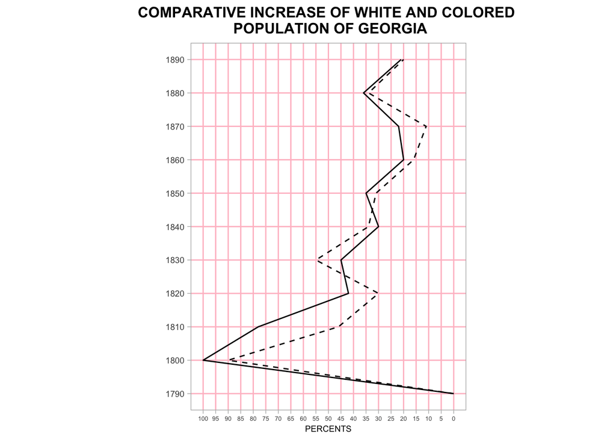

```r
ggplot(georgia_pop, aes(x = Year, y = percent)) +
  geom_line(aes(y = White), linetype = "dashed") +
  geom_line(aes(y = Colored), linetype = "solid") +
  scale_y_reverse(breaks=seq(0, 100, 5)) +
  coord_flip()  +
  ggtitle("COMPARATIVE INCREASE OF WHITE AND COLORED \n POPULATION OF GEORGIA") +
  xlab("") +
  ylab("PERCENTS") +
  xlim(1790, 1890) +
  scale_x_continuous(breaks=seq(1790, 1890, 10)) +
  scale_linetype_manual(values=c("dashed", "solid")) +
  theme_light() +
  theme(panel.grid.major = element_line(size = 0.5, linetype = "solid",
                                colour = "#ffc0cb"),
        panel.grid.minor = element_line(size = 0.5, linetype = "solid",
                                colour = "white"),
        plot.title = element_text(hjust = 0.5, size = 12, face = "bold")) +
  theme(legend.position="bottom",
        legend.title = element_blank(),
        legend.text = element_text(size = 5),
        axis.title.x = element_text(size = 7),
        axis.text.y = element_text(size = 7),
        axis.text.x = element_text(size = 5)) +
  theme(aspect.ratio=4/3)
```

challenge02: Conjugal Condition

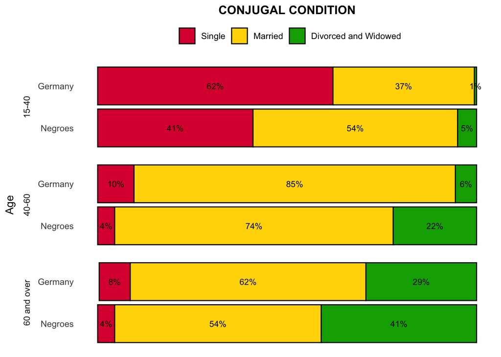

```r
conjugal <- tuesdata$conjugal
conjugal <- as.data.frame(conjugal)

conjugal <- melt(conjugal, id.vars=c("Population", "Age"))
conjugal$Population <- factor(conjugal$Population,levels = c("Negroes", "Germany"))
conjugal$variable <- factor(conjugal$variable,levels = c("Single", "Married", "Divorced and Widowed"))

conjugal$perc <- paste0(as.character(round(conjugal$value, 0)), "%")

ggplot(conjugal, aes(x = Population, y = value)) +
  geom_bar(aes(fill = variable), color = "black", position = "stack", stat = "identity") +
  facet_wrap(~Age, dir = "v", switch="both") +
  geom_text(aes(label = perc, group = variable), position = position_stack(vjust = 0.5), size = 3) +
  xlab("Age") +
  coord_flip() +
  scale_y_reverse() +
  theme_minimal() +
  scale_fill_manual(values = c("Single" = "#dc143c", "Married" = "#ffd700", "Divorced and Widowed" = "#00aa00"))  +
  ggtitle("CONJUGAL CONDITION") +
  theme(legend.position="top",
        legend.title = element_blank(),
        plot.title = element_text(hjust = 0.5, size = 12, face = "bold"),
        axis.title.x = element_blank(),
        axis.text.x = element_blank(),
        axis.text.y = element_text(hjust = 1),
        axis.ticks.x = element_blank(),
        axis.ticks.y = element_blank(),
        strip.placement = "outside") +
  theme(panel.grid.major = element_line(size = 0.5, linetype = "solid",
                                colour = "white"),
        panel.grid.minor = element_line(size = 0.5, linetype = "solid",
                                colour = "white"))
```

Additional Challenges:

challenge03: Occupations of Negroes and Whites in Georgia

challenge04: Proportion of Freeman and Slaves Among American Negroes

challenge05: Income and Expenditure of 150 Negro Families in Atlanta, GA, USA

challenge06: City and Rural Population 1890

challenge07: Assessed Value of Household and Kitchen Furniture Owned by Georgia Negroes.

challenge08: The Georgia Negro. A Social Study by W.E.Burghardt Du Bois

challenge09: Migration of Negroes

challenge10: Negro Population of Georgia by Counties